# CleanCodeAndDirtyTricks 🚀

## Session 01: 101 into Clean Coding and (basic) Program Structure

[figure not shown]

@#DKOP#TTK#WJSZ#PHYSICS#ComputerScience

# 👋 About Me: Kristóf Benedek

*Physicist & Computational Scientis*

## 🌍 Background

- Passionate about **mathematical modeling of nature**
- Strong interest in connecting **numbers with real-world phenomena**
- Experienced in:
  - **Statistical physics**
  - **Network science & synchronization**
  - **Computational physics**
  - **AI applications & Computer Vision**

## 🌐 Based In

**Budapest, Hungary** 🇭🇺

**BME and HUN-REN MFA EK, KRL**

## 📬 Contact

- 📧 kristof.benedek@edu.bme.hu
- 🐙 [GitHub](https://github.com/bkris2315)
- 💼 [LinkedIn](https://www.linkedin.com/in/kristof-benedek/)

### > *“Code is how I translate complexity into clarity.”*

# 0. About the course

## A 4-Session Interactive Seminar Series

## 🚀 What’s This About?

Welcome to a practical and engaging seminar series on writing better code, building smarter workflows, and leveraging modern tools like AI and GitHub to level up your software development game.

## 🧵 Topics We'll Explore

1. **🧼 Clean Code**
   - Writing readable, maintainable code
   - Documentation, naming, class/function design, typing
2. **⚙️ Python Code Optimization**
   - Vectorization, parallelization, JIT, GPU use
   - Object-oriented structure & debugging tips
3. **🤖 AI in Development**
   - ChatGPT & GitHub Copilot
   - Prompting, productivity, hallucinations, confidentiality
4. **🌐 GitHub & Project Management**
   - Repo structure, PR workflow, branching, task management
   - Beautiful READMEs, deployment basics

## 🧠 Bonus (If Time Allows)

- Symbolic math with Python
- AI insights: transformers, contrastive learning, distillation, object detection

## 📅 Logistics

- **Sessions:** 4 total (flexible ±1)
- **When:** Fridays, 16:00 CET, (~90 mins each) (mind the official holidays due to Easter!)
- **Format:** In-person, online, hybrid
- **Style:** Interactive talks, code snippets, slides = minimal + focused
- **Resources:** All materials hosted on a GitHub repo

## 🧩 Why Join?

- Learn best practices for real-world development
- Sharpen both your coding and collaboration skills
- Get hands-on with tools that modern devs actually use

### > *Come write code that doesn’t just work — but works beautifully.*

# I. Introduction

[figure not shown]

# Why do we care?

- Writing clean code is a timeless, crucial skill in software development.
- Regardless of tech trends, **code remains the medium** through which we solve problems.

## What Prevents Clean Code?

**Number one reason:**

### > “I’ll clean it up later.”

> **Pro Tip:** “Later” never comes.
- Works... *for now*.
- Causes:
  - Tight deadlines
  - Inexperience
  - Sloppy habits
- Results:
  - Bugs 🐛
  - Slower development 🐢
  - Higher long-term costs 💸

## 💰 The Total Cost of Owning a Mess

- Messy code = long-term pain
- Every messy line today steals time tomorrow
- Clean code = investment in **productivity**

## ⛺ The Boy Scout Rule

> *“Leave the campground cleaner than you found it.”*
- Make small improvements constantly
- Clean code is not a one-time event — it’s a habit

# Clean code saves **time, bugs, and sanity** long-term

## 🧼 What Is Clean Code?

- Easy to read, maintain, extend
- Key principles:
  - Single Responsibility
  - Minimize dependencies
  - Avoid duplication
- Habits:
  - Meaningful names
  - Small functions
  - Tests!

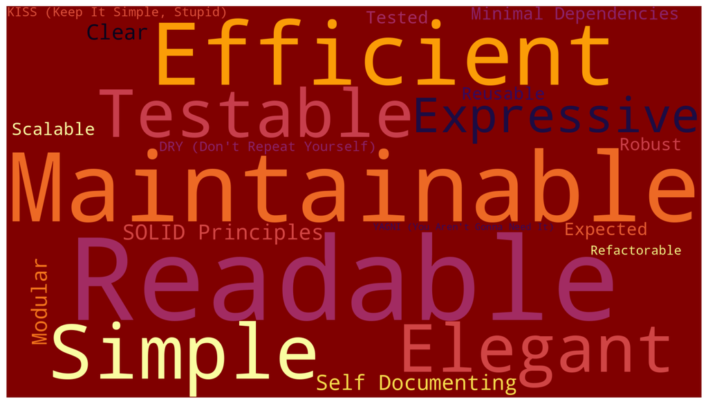

## 🤯 What Clean Code Is NOT

- Complex, over-engineered code
- Duplicated or misleading code
- Code that hides logic or purpose

# II. Meaningful Names

[figure not shown]

## 🧠 Why Names Matter

- Naming is **one of the hardest problems** in programming.
- Poor naming leads to **confusion, bugs, and harder maintenance**.
- Your code is read more often than it’s written — name things like you care!

If your naming is bad, you need comments. **A well-written code does not need any additional comment** apart from a docstring. More on comments in Ch. IV.

## 🎯 Use Intention-Revealing Names

**Bad:**

```
int d;
```

**Good:**

```
int daysUntilExpiration;
```

### > Names should clearly describe what the variable does or represents.

## 🚫 Avoid Disinformation

**Bad:**

```
int temp = 20; // temp = temporary? temperature?
```

**Good:**

```
int temperatureCelsius = 20;
```

### > Misleading names are worse than vague ones — don’t lie to the reader.

## 🧍 Make Meaningful Distinctions

**Bad:**

```
int data;
int data1;
```

**Good:**

```
int userData;
int adminData;
```

### > Names must differentiate with purpose, not just slight variations.

## 📣 Use Pronounceable Names

**Bad:**

```
int genymdhmsepch;
```

**Good:**

```
int generationTimestampEpoch;
```

### > If you can't say the variable name, you probably won't discuss it either.

## 🔍 Use Searchable Names

**Bad:**

```
int x;
```

**Good:**

```
int maxUserCount;
```

## > Short names make searching and understanding harder. Use descriptive terms.

## 🧠 Avoid Mental Mapping

**Bad:**

```
int r; // radius? ratio? result?
```

**Good:**

```
int gardenRadius;
```

### > Don’t make others decode your intentions — be explicit.

## 🧾 Class & Method Names

#### **Classes**: Use nouns or noun phrases

**Bad:**

```
class Data;
```

**Good:**

```
class Customer;
```

#### **Methods**: Use verbs or verb phrases

**Bad:**

```
void data();
```

**Good:**

```
void saveCustomerData();
```

### > Class: what it is. Method: what it does.

## ♻️ Pick One Word per Concept

**Bad:**

```
fetchData();
getUserData();
retrieveAdminData();
```

**Good:**

```
fetchData();
fetchUserData();
fetchAdminData();
```

### > Be consistent with terminology across the project.

## 🏷 Use Domain-Specific Names

**Bad:**

```
int count;
```

**Good:**

```
int overdueBookCount;
```

### > Use the language of your domain to improve relevance and clarity.

## 📦 Add Meaningful Context

**Bad:**

```
int value;
```

**Good:**

```
int orderValue;
```

### > Add just enough context to make the name self-explanatory.

## 🧾 Mainstream Naming Conventions

| Case Style | Used For | Example | Common In |
| --- | --- | --- | --- |
| **camelCase** | Variables, functions | `totalCount`, `saveUser()` | JavaScript, Java, C#, Swift |
| **PascalCase** | Classes, types, constructors | `CustomerAccount`, `AppView` | C#, Java, TypeScript |
| **snake_case** | Variables, functions (esp. in Python) | `total_count`, `save_user()` | Python, Ruby, C, C++ |
| **SCREAMING_SNAKE_CASE** | Constants | `MAX_CONNECTIONS`, `DEFAULT_TIMEOUT` | C, Python, Go, many more |
| **kebab-case** | Filenames, URLs, CLI options | `clean-code.md`, `--user-name` | HTML/CSS files, URLs, CLI |
| **dot.case** | Config files, package names | `clean.code.config` | JSON, npm, file systems |

### ✅ General Naming Best Practices

- **Be consistent**: Stick to one convention per project.
- **Reflect meaning**: Names should describe purpose, not implementation.
- **Avoid abbreviations** unless widely accepted (e.g. `id`, `url`).
- **Pluralize collections**: `users` for a list, `user` for a single object.
- **Prefix booleans** with verbs: `isVisible`, `hasAccess`, `canEdit`.

## Summary

**✅ Do:**

- Reveal intent
- Be specific
- Use consistent terms
- Favor domain terminology

**🚫 Avoid:**

- Vague, short names
- Misleading labels
- Arbitrary distinctions
- Jargon or abbreviations

### > “Naming is not just about identification — it’s about communication.”

Well-named code explains itself and reduces the need for comments. It’s one of the most powerful tools in writing clean, professional software.

# III. Functions

*A guide to writing clean, small, and meaningful functions*

[figure not shown]

## 📏 Keep It Small

> “Functions should be short. Really short."

**Why?**

- Easier to read and understand
- Easier to reuse and test
- Tells a story, one step at a time

### Example

### ⛔️ **Bad**

```
def process_user(user_data):
    # many unrelated operations here
    ...
```

## ✅ **Good**

```
def validate_user(user_data): ...
def store_user(user_data): ...
def notify_user(user_data): ...
```

```
def elapse(year):
    days = 365
    if year % 4 == 0 or (year % 100 == 0 and year % 400 == 0):
        days += 1
    for day in range(1, days + 1):
        print(f"Day {day} of {year}")
```

```
def is_leap(year): ...
def elapse(year):
    days = 366 if is_leap(year) else 365
    ...
```

## 🎯 Do One Thing

### ⛔️ Bad (Python):

```
def create_user(name, email, password):
    if not name:
        raise ValueError("Invalid name")
    store_user_in_db(name, email, hash_password(password))
```

### ✅ Good (Python):

```
def validate_name(name): ...
def hash_password(password): ...
def store_user(name, email, hashed_pw): ...
```

## 🧠 Use Descriptive Names

**Good names tell the reader what the function does.**

### ⛔️ Bad (C):

```
int doIt(int a, int b) {
    return a + b;
}
```

### ✅ Good (C):

```
int addTwoNumbers(int firstNumber, int secondNumber) {
    return firstNumber + secondNumber;
}
```

## 🧮 Minimize Function Arguments

- Ideal: **0 (niladic)**
- Good: **1 (monadic)**
- Acceptable: **2 (dyadic)**
- Avoid: **3+ (triadic/polyadic)** unless necessary

### 🧵 Bundle related args:

```
# Instead of:
def draw_box(x, y, width, height): ...

# Prefer:
def draw_box(rect):  # where rect is a namedtuple or object
```

## ❓ Command–Query Separation

> Functions should either **do something** or **answer something**, not both.

### ⛔️ Bad:

```
def set_username(username):  # returns success?
    ...
```

### ✅ Good:

```
def username_exists(username): ...
def update_username(username): ...
```

## 🚨 Prefer Exceptions Over Error Codes

### ⛔️ Bad (C-style):

```
int openFile(char* path) {
    if (path == NULL) return -1;
    // ...
    return 0;
}
```

### ✅ Good (Python):

```
def open_file(path):
    if not path:
        raise ValueError("Invalid path")
```

## 🔁 Don't Repeat Yourself (DRY), again

Avoid copy-pasting logic — abstract instead.

### ⛔️ Bad (Python):

```
def sum_two(a, b): return a + b
def sum_three(a, b, c): return a + b + c
```

### ✅ Good:

```
def sum_all(*args):
    return sum(args)
```

## ✅ Recap: Function Best Practices

| Principle | Description |
| --- | --- |
| **Small** | Short and focused |
| **Do One Thing** | No multitasking |
| **Descriptive Names** | Self-documenting code |
| **Few Arguments** | Prefer 0–2 args |
| **Command ≠ Query** | Clear responsibility |
| **Use Exceptions** | Don’t return error codes |
| **DRY** | Reuse logic, avoid duplication |

### > *“Clean functions are like clean tools: precise, sharp, and made for a single task.”*

Let your functions tell a story — clearly, one well-named step at a time.

# IV. Comments Are Bad

*When (not) to comment your code*

[figure not shown]

## 🧼 The Philosophy

> *“Don’t comment bad code — rewrite it.”*  
> — Robert C. Martin
- Comments are a **necessary evil**, not a best practice.
- Code should be **self-explanatory** — comments are a fallback.
- Most comments decay into **misleading noise** over time.

## ⚠️ Why Comments Can Be Bad

- **Get outdated** as code changes
- Can **lie** or mislead
- Are often used to explain **unclear code**
- Create **maintenance burden**

## 🧠 Code Should Speak For Itself

Instead of this:

```
# increase balance by 10%
balance = balance + balance * 0.1
```

Do this

```
def apply_interest(balance, rate=0.1):
    return balance * (1 + rate)
```

## ✅ When Comments Are Useful

### 📜 Legal Comments

Licensing and copyright info.

### 🧾 Informative Comments

Explaining non-obvious things (e.g., regexes, hardware constraints).

### 🧠 Intent Explanation

Why something is done a certain way, not *what* is being done.

```
# Priority queue used for Dijkstra's algorithm
queue = PriorityQueue()
```

### 🔍 Clarification

For unavoidable obscurities:

```
# API returns 0 for success, 1 for failure 🤷
if api_call() == 0: ...
```

### ⚠️ Warning of Consequences

```
# ⚠️ This test takes ~5 min to run!
def test_large_dataset(): ...
```

### 🛠 TODOs

Track incomplete tasks (but remove when resolved).

```
# TODO: Add support for edge cases
```

### 📣 Amplification

Highlighting subtle but crucial detail:

```
# Trim to avoid trailing whitespace bugs
cleaned_name = name.strip()
```

### 📚 Javadocs / Public API Docs

Needed for external consumers, but must be maintained.

## 🚫 Bad Comment Patterns

| Type | Problem |
| --- | --- |
| **Mumbling** | Vague, unclear wording |
| **Redundant** | Repeats what the code already shows |
| **Misleading** | No longer accurate |
| **Mandated** | Required but meaningless docs |
| **Journal Comments** | Version history — use Git instead |
| **Noise** | Adds clutter, not clarity |

## ❌ Examples of Bad Comments

```
# increment i by 1
i += 1  # ← no need for that comment
```

```
// Default constructor
MyClass::MyClass() {}
```

```
// Changed on Jan 2023
// Added null check
```

> Use version control (Git!) instead.

## 🧼 Comment TL;DR

| 💡 Use Comments For | 🚫 Avoid Comments That |
| --- | --- |
| Legal / license info | State the obvious |
| Intent or rationale | Get out-of-sync easily |
| Real warnings / TODOs | Replace poor naming |
| Public API documentation | Could be refactored instead |

### > *“The best comment is the one you didn’t need to write because your code was clear enough.”*

# **Refactor > explain.**

# And try to avoid this... seriously

[figure not shown]

# V. Venvs and docstrings

[figure not shown]

# 📄 Writing Good Docstrings (Google Style)

> *“Comments explain **why**, docstrings explain **how to use**.”*

## 🧠 Why Use Docstrings?

- Clarify usage of your functions/classes/modules
- Help others (and future you) understand API contracts
- Power tools like `help()`, IDEs, and doc generators

## ✅ Google Style Format

```
def get_user(id: int, include_inactive: bool = False) -> dict:
    """
    Fetch a user by ID.

    Args:
        id (int): Unique user ID.
        include_inactive (bool): Include inactive users. Default is False.

    Returns:
        dict: User data dictionary.

    Raises:
        ValueError: If ID is not found or invalid.
    """
```

### ✨ Tips for Great Docstrings

- First line = **short summary** (ends with period)
- Use **imperative tone** (“Return...” not “Returns…”)
- Include `Args`, `Returns`, `Raises`, and optional `Examples`
- Document non-obvious behavior, defaults, edge cases

# 🧪 Virtual Environments in Python

> *“A virtual environment is like a sandbox for your Python project.”*

## 🧩 Why Use Virtual Environments?

- Isolate project dependencies (no system-wide mess)
- Avoid version conflicts between projects
- Reproducible environments for collaboration or deployment

## 🛠️ Creating One

```
# Create
python -m venv venv

# Activate (Linux/macOS)
source venv/bin/activate

# Activate (Windows)
venv\Scripts\activate
```

## 🧹 Best Practices

- Name it `.venv` or `venv`, and **add to `.gitignore`**
- Use `requirements.txt` or `pip freeze > requirements.txt`
- Deactivate with:

```
deactivate
```

## 📦 With pip

```
# Install packages locally to your env
pip install numpy

# Freeze for others
pip freeze > requirements.txt

# Reinstall for new devs
pip install -r requirements.txt
```

### > *“If your project has a `venv` and a `README`, you're halfway to being professional.”*

# References

1. [Clean Code Notes](https://medium.com/@akineralkan/list/clean-code-notes-bb47e308d51e) by Akiner Alkan
2. Robert C. Martin: [Clean Code](https://www.amazon.com/Clean-Code-Handbook-Software-Craftsmanship/dp/0132350882)
3. [Clean Code in Python](https://ep2016.europython.eu/media/conference/slides/clean-code-in-python.pdf) by Mariano Anaya from EuroPython